# Effects of Loan Features on Borrower Rate

## by Ezekiel Ifeoluwa Deborah

## Distribution of Borrower Rate

> The distribution of borrower rate is long tailed with a very high peak at 0.32%. Most of the borrowers have a borrower rate of 0.32% and below

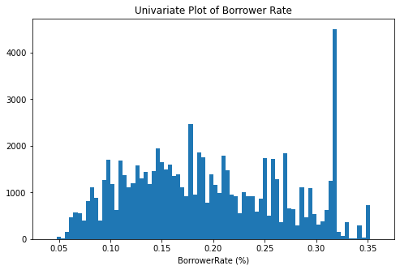

## Ditribution of Prosper Score

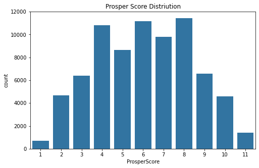

## Distribution of Credit Score Range

Credit Scores are three digit numbers, typically between 300 and 900, designed to represent your credit risk, or the likelihood you will pay your bills on time. Those with higher credit scores generally recieve more favorable credit terms, which may translate into lower payments and lower Borrower Rates.  
Credit scores ranges vary based on the credit scoring model used, but are generally similar to the following:

- Poor: 300-579
- Fair: 580-699
- Good: 670-739
- Very good: 740-799
- Excellent: => 800

There is a high level of frequency from between approximately 680 to 725 after which it reduces and the distribution slopes downwards.  
Most of the borrowers have a between good and excellent credit scores.

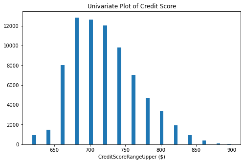

## Borrower Rate by Prosper Score

Prosper score have a strong negative relationship, as prosper score reduces , borrower rate increases. The higher(i.e the better) a borrower's prosper score the lower their borrower rate.

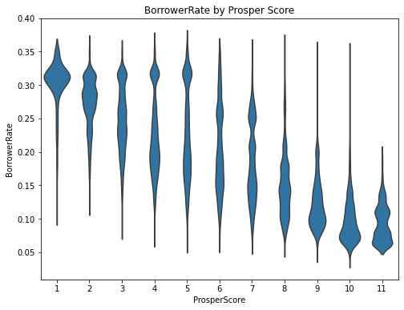

## Borrower Rate by Credit Score

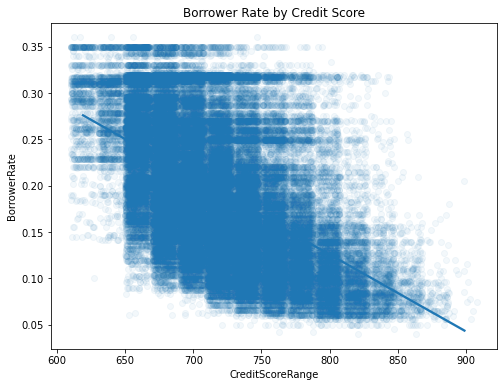

## Borrower Rate by Prosper Score and Loan Term

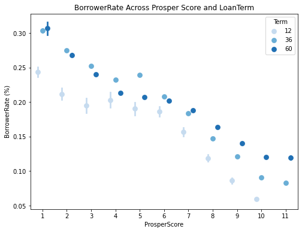